# Lab 3 Key

Author

Nathaniel Grimes

## Load in data and packages

```r
library(tidyverse)
library(tidymodels)
library(here)

t_df<-read_csv(here("data", "titanic_survival.csv"))
```

## ML Framework

Write a description of how you go about applying machine learning problems. If you drew a diagram, share with a neighbor and discuss.

1. Research Question
2. Data Exploration/Cleaning
3. Data Split
4. Build Models
   1. Data Preprocessing
   2. Train Model
   3. Tune
   4. Evaluate Performance
   5. Model Selection
5. Finzalize Model
6. Interpret and Visualize Results

## Tidymodels Overview

The creators of `tidyverse` have created a new package called `tidymodels` that is designed to make machine learning more accessible to R users. The package is designed to work with the `tidyverse` and `tidydata` principles.

## Defining a Research Question

What are we trying to solve? The crucial step of any scientist that can take years to define and perfect.

**What factors led to the survival of passengers on the Titanic?**

How will go about solving our question? Use a classification algorithm to predict the survival of passengers on the Titanic. Interpret the variables that control observed outcomes.

In real life, we would have to go out and collect the data. Today, we will use the `titanic` dataset from the `titanic` package.

## Data Exploration/Cleaning

Take 15 minutes to explore the data. Are there any immediate changes to the data that we need to change? What relationships can you see through graphs? What variables could be of interest to predict survival of passengers on the Titanic?

```r
surv_df <- t_df %>%
  mutate(survived = factor(survived),   ### categorical outcome variables need to be factors
         pclass   = factor(pclass)) %>% ### turn some predictors to factor
  select(-cabin, -ticket) ### lots of NAs here - and not likely to be very helpful
```

Here are some quick examples that I did.

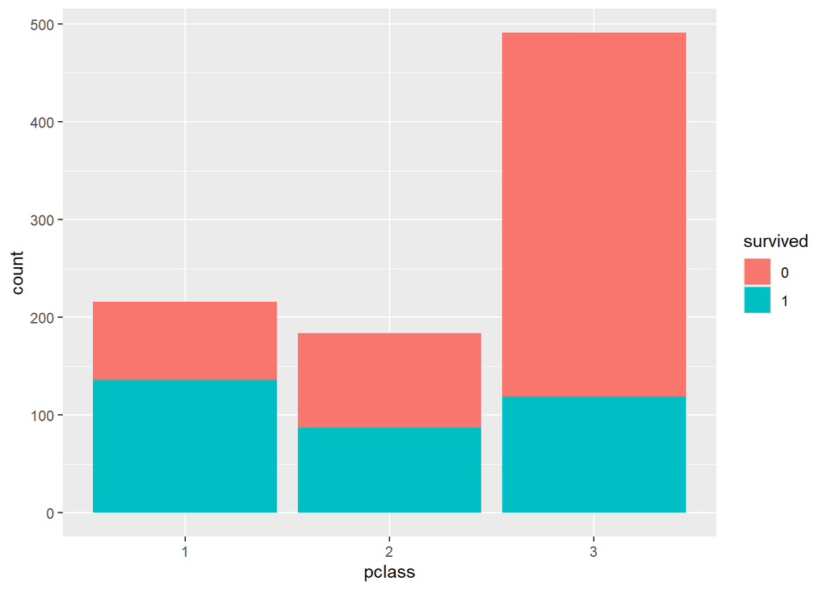

```r
ggplot(surv_df, aes(x = pclass, fill = survived)) +
  geom_bar()
```

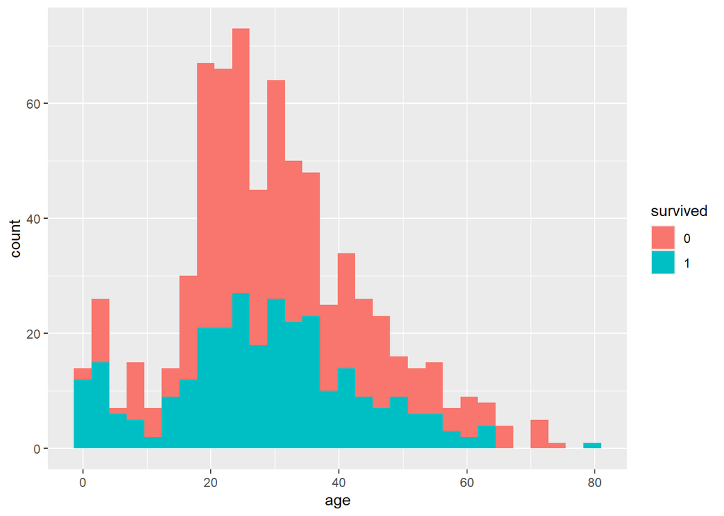

```r
ggplot(surv_df, aes(x = age, fill = survived)) +
  geom_histogram()
```

## Data Split

We will set aside (“partition”) a portion of the data for building and comparing our models (80%), and a portion for testing our models after we’ve selected the best one (20%). NOT the same as folds - that will happen in the training/validation step.

```r
### Check balance of survived column
surv_df %>%
  group_by(survived) %>%
  summarize(n = n()) %>%
  ungroup() %>%
  mutate(prop = n / sum(n))
```

```
# A tibble: 2 × 3
  survived     n  prop
  <fct>    <int> <dbl>
1 0          549 0.616
2 1          342 0.384
```

Tidymodels will split the data and label it for us.

```r
set.seed(123)

surv_split <- initial_split(surv_df, prop = 0.80,strata = survived)
  ### stratified on `survived`; training and test splits will both have ~60/40% survived = 0/1
surv_train_df <- training(surv_split)
surv_test_df <- testing(surv_split)
```

Check to make sure the data has the same proportion of splits. Why is it important to maintain the same proportion of splits?

```r
surv_train_df %>%
  group_by(survived) %>%
  summarize(n = n()) %>%
  ungroup() %>%
  mutate(prop = n / sum(n))
```

```
# A tibble: 2 × 3
  survived     n  prop
  <fct>    <int> <dbl>
1 0          439 0.617
2 1          273 0.383
```

```r
surv_test_df %>%
  group_by(survived) %>%
  summarize(n = n()) %>%
  ungroup() %>%
  mutate(prop = n / sum(n))
```

```
# A tibble: 2 × 3
  survived     n  prop
  <fct>    <int> <dbl>
1 0          110 0.615
2 1           69 0.385
```

## Model Building

Constructing models in `tidymodels` is frighteningly simple. We tell R which kind of algorithm we want to build (model), what package the algorithm should come from (engine), and how to construct it.

```r
log_md <- logistic_reg() %>%
  set_engine("glm")

lasso_md<- logistic_reg(penalty = 0.037,mixture=1) %>%
  set_engine("glmnet")
```

### Data Preprocessing

We use receipes to convert our data into the format best suited to our chosen models. Basically we tell R to *consistently* transform our data between all training and testing sets. This prevents data leakage and ensures that our models are trained on the same data.

We’re going to build two models: a logistic regression and a lasso logistic regression model.

```r
glm_rec<-recipe(survived ~ sex + pclass, data = surv_train_df)

# steps we need to do to prepare data for lasso

lasso_rec<-recipe(survived~.,data=surv_train_df) %>%
  update_role(passenger_id, new_role = "ID") %>%
  step_rm(name,age) %>%
  step_unknown(all_nominal(),-all_outcomes()) |>
  step_dummy(all_nominal(),-all_outcomes()) |>
  step_zv(all_numeric(),-all_outcomes()) |>
  step_normalize(all_numeric(),-all_outcomes())
```

### Train Model

First we create a workflow that combines all the models and the receipes to control the data. Then we use that consistent pattern to fit our model. First let’s compare the models one time. Add comments to the following code chunk to describe what each step is doing. Feel free to run code.

```r
# First the logistic regression

log_wf <- workflow() %>%
  add_recipe(glm_rec) %>%
  add_model(log_md)

log_fit<-log_wf %>%
  fit(surv_train_df)

log_test<-surv_test_df |>
  mutate(predict(log_fit, new_data = surv_test_df)) |>
  mutate(predict(log_fit,new_data = surv_test_df, type='prob'))

table(log_test$survived, log_test$.pred_class)
```

```
     0  1
  0 93 17
  1 17 52
```

```r
lasso_wf<-workflow() %>%
  add_model(lasso_md) %>%
  add_recipe(lasso_rec)

lasso_fit<-lasso_wf |>
  fit(surv_train_df)


lasso_test<-surv_test_df |>
  mutate(predict(lasso_fit, new_data = surv_test_df)) |>
  mutate(predict(lasso_fit,new_data = surv_test_df, type='prob'))

table(lasso_test$survived, lasso_test$.pred_class)
```

```
     0  1
  0 93 17
  1 17 52
```

### Evaluate Performance

Measure the accuracy using the `accuracy` function from the `yardstick` package for each model.

```r
log_test |>
  accuracy(truth = survived, estimate = .pred_class)
```

```
# A tibble: 1 × 3
  .metric  .estimator .estimate
  <chr>    <chr>          <dbl>
1 accuracy binary         0.810
```

```r
lasso_test |>
  accuracy(truth = survived, estimate = .pred_class)
```

```
# A tibble: 1 × 3
  .metric  .estimator .estimate
  <chr>    <chr>          <dbl>
1 accuracy binary         0.810
```

Calculate the `ROC AUC` for each model.

```r
### Calculate area under curve - 50% is random guessing, 100% is perfect classifier
log_test |>
  yardstick::roc_auc(truth = survived, .pred_0)
```

```
# A tibble: 1 × 3
  .metric .estimator .estimate
  <chr>   <chr>          <dbl>
1 roc_auc binary         0.856
```

```r
lasso_test |>
  yardstick::roc_auc(truth = survived, .pred_0)
```

```
# A tibble: 1 × 3
  .metric .estimator .estimate
  <chr>   <chr>          <dbl>
1 roc_auc binary         0.849
```

### Model Selection

One run of the model is not enough to determine which model is better. We need to run the model multiple times to determine which model is better. We can use cross-validation to determine which model is better. Instead of for loops or purrr, tidymodels as built in functions to do this for us.

```r
set.seed(12)

folds<-vfold_cv(surv_train_df, v=10, strata = survived)

log_fit_folds<- log_fit |>
  fit_resamples(folds)

collect_metrics(log_fit_folds)
```

```
# A tibble: 3 × 6
  .metric     .estimator  mean     n std_err .config
  <chr>       <chr>      <dbl> <int>   <dbl> <chr>
1 accuracy    binary     0.781    10 0.0123  Preprocessor1_Model1
2 brier_class binary     0.151    10 0.00699 Preprocessor1_Model1
3 roc_auc     binary     0.828    10 0.0154  Preprocessor1_Model1
```

```r
lasso_res<-lasso_wf %>%
  fit_resamples(folds)

collect_metrics(lasso_res)
```

```
# A tibble: 3 × 6
  .metric     .estimator  mean     n std_err .config
  <chr>       <chr>      <dbl> <int>   <dbl> <chr>
1 accuracy    binary     0.781    10 0.0123  Preprocessor1_Model1
2 brier_class binary     0.157    10 0.00612 Preprocessor1_Model1
3 roc_auc     binary     0.830    10 0.0153  Preprocessor1_Model1
```

Which model do we choose?

Let’s look at the actual models to get a better understanding.

```r
log_fit |>
  extract_fit_parsnip()|>
  tidy()
```

```
# A tibble: 4 × 5
  term        estimate std.error statistic  p.value
  <chr>          <dbl>     <dbl>     <dbl>    <dbl>
1 (Intercept)    2.28      0.243      9.42 4.50e-21
2 sexmale       -2.55      0.204    -12.5  1.20e-35
3 pclass2       -0.877     0.272     -3.23 1.25e- 3
4 pclass3       -1.93      0.236     -8.19 2.58e-16
```

```r
lasso_fit |>
  extract_fit_parsnip() |>
  tidy()
```

```
# A tibble: 9 × 3
  term        estimate penalty
  <chr>          <dbl>   <dbl>
1 (Intercept)  -0.570    0.037
2 sib_sp        0        0.037
3 parch         0        0.037
4 fare          0.0746   0.037
5 pclass_X2     0        0.037
6 pclass_X3    -0.473    0.037
7 sex_male     -0.937    0.037
8 embarked_Q    0        0.037
9 embarked_S    0        0.037
```

Lasso set many of the parameters to zero. How do you interpret this model? Why would you want to use as opposed to simple logistic regression?

### Finalize Model

```r
final_log<-log_wf |>
  last_fit(surv_split)
```

## Interpret and Visualize Results

Everything is stored in a `workflow` object. We can extract the coefficients from the logistic regression model using `extract_fit_parsnip`. The `tidy` function will make the output more readable. Describe the coefficients and what they mean. Create a clean table of the model output.

```r
final_log |>
  extract_fit_parsnip() |>
  tidy() |>
  mutate(odds=exp(estimate),
         prob=odds/(1+estimate))
```

```
# A tibble: 4 × 7
  term        estimate std.error statistic  p.value   odds    prob
  <chr>          <dbl>     <dbl>     <dbl>    <dbl>  <dbl>   <dbl>
1 (Intercept)    2.28      0.243      9.42 4.50e-21 9.82    2.99
2 sexmale       -2.55      0.204    -12.5  1.20e-35 0.0783 -0.0506
3 pclass2       -0.877     0.272     -3.23 1.25e- 3 0.416   3.38
4 pclass3       -1.93      0.236     -8.19 2.58e-16 0.145  -0.156
```

Please give this a go on your own with the post-lab exercise. I will be walking around to assist.

## Tuning example

This just shows how to hypertune the `glmnet` penalty parameter. We’ll cover more when we get to random forests with Yutian.

```r
set.seed(123)

lambda_grid <- grid_regular(penalty(), levels = 50)

lasso_md_tune<- logistic_reg(penalty = tune(),mixture=1) %>%
  set_engine("glmnet")

lasso_wf<-workflow() %>%
  add_model(lasso_md_tune) %>%
  add_recipe(lasso_rec)


set.seed(2020)
lasso_grid <- tune_grid(
  lasso_wf,
  resamples = folds,
  grid = lambda_grid
)

lasso_grid %>%
  collect_metrics()
```

```
# A tibble: 150 × 7
    penalty .metric     .estimator  mean     n std_err .config
      <dbl> <chr>       <chr>      <dbl> <int>   <dbl> <chr>
 1 1   e-10 accuracy    binary     0.780    10 0.0135  Preprocessor1_Model01
 2 1   e-10 brier_class binary     0.153    10 0.00683 Preprocessor1_Model01
 3 1   e-10 roc_auc     binary     0.833    10 0.0148  Preprocessor1_Model01
 4 1.60e-10 accuracy    binary     0.780    10 0.0135  Preprocessor1_Model02
 5 1.60e-10 brier_class binary     0.153    10 0.00683 Preprocessor1_Model02
 6 1.60e-10 roc_auc     binary     0.833    10 0.0148  Preprocessor1_Model02
 7 2.56e-10 accuracy    binary     0.780    10 0.0135  Preprocessor1_Model03
 8 2.56e-10 brier_class binary     0.153    10 0.00683 Preprocessor1_Model03
 9 2.56e-10 roc_auc     binary     0.833    10 0.0148  Preprocessor1_Model03
10 4.09e-10 accuracy    binary     0.780    10 0.0135  Preprocessor1_Model04
# ℹ 140 more rows
```

```r
lowest_rmse <- lasso_grid %>%
  select_best(metric="roc_auc") #use this metric
```